# Soal 1: Pemahaman Machine Learning

Jawab/Kerjakan pertanyaan/perintah di bawah ini dengan bahasa kalian sendiri:

- Apa itu machine learning?
- Apa itu data feature dan data target?
- Apa Perbedaan Supervised Learning dan Unsupervised Learning?
- Apa Jenis2 yang ada di dalam Supervised Learning? Jelaskan Perbedaannya!
- Apa perbedaan Hyperparameter dan Parameter?
- Sebutkan Langkah-langkah dalam mengaplikasikan algoritma apapun dalam machine learning!

Jawab:

- Machine Learning adalah cabang dari kecerdasan buatan yang mana machine learning merupakan mesin yang belajar, belajar dari data-data yang ada untuk membuat sebuah keputusan atau prediksi di masa depan.
- Data feature merupakan data yang berisi variabel independent, ia berfungsi sebagai predictor yang berperan dalam melakukan prediksi, sedangkan data target merupakan data yang berisi variabel dependent yang digunakan sebagai label dimana label merupakan hasil dari prediksi.
- Perbedaan Supervised Learning dan Unsupervised learning terdapat pada label. pada supervised learning terdapat label yang jelas dan akan menghasilkan output yang jelas sedangkan pada unsupervised learning tidak terdapat label dan output kurang jelas.
- Dalam Supervised Learning trdapat 2 keluaran yaitu Classification dan Regression. Perbedaan dari keduanya terdapat pada hasil outputnya. Jika pada classification output berupa class label sedangkan pada regression output berupa quantity yang continous(berupa nilai yang memiliki rentang tertentu).
- Perbedaan antara Hyperparameter dan Parameter adalah seperti berikut: Hyperparameter didefinisikan diawal pembuatan objek model sedangkan parameter dihasilkan diakhir, parameter terdapat dalam model yang telah didefinisikan diawal tadi.
- Step-step dalam mengaplikasikan algoritma dalam machine learning: Pilih model atau algoritma yang akan digunakan, Pilih Hypermeter ketika membuat objek model, Pisahkan antara data feature dan data target, perintahkan model untuk mempelajari data dengan metode.fit(), aplikasikan model ke dalam test data dengan menggunakan metode .predict() untuk supervised learning atau .transform() dan .predict() untuk unsupervised learning.

# Soal 2: Pemahaman Machine Learning

Pelajarilah secara garis besar suatu model/algoritma machine learning, kemudian aplikasikan untuk membuat model bagi data (variable x, y) di bawah ini. Kemudian buatlah prediksi terhadap data training dan data baru di interval 20-30.

- Plot data asli, data hasil prediksi terhadap data training, data hasil prediksi terhadap data baru
- Tunjukan beberapa parameter yang dimiliki model yang telah kalian buat

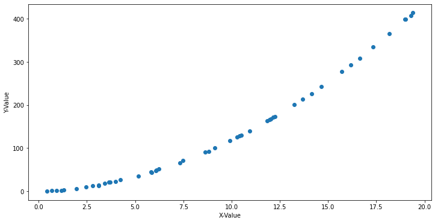

```python
import matplotlib.pyplot as plt
import numpy as np

rng = np.random.RandomState(42)
x = 20 * rng.rand(50)
y = x**2 + 2 * x + - 1 + rng.randn(50)

# data yang akan di prediksi
x_new = np.arange(20, 30, 0.5)

fig, ax = plt.subplots(figsize=(12, 6))
ax.scatter(x, y)
ax.set_xlabel('X-Value')
ax.set_ylabel('Y-Value')
plt.show()
```

Contoh jawaban hasil pembuatan model dengan algoritma DecisionTreeRegressor (jawaban tidak harus sama):

[figure not shown]

Contoh jawaban parameters (tidak harus sama):

- Feature Importance : array([1.])
- n features : 1

Tree Graph :

[figure not shown]

```python
# Code here
from sklearn.tree import DecisionTreeRegressor
from sklearn import tree

rgr = DecisionTreeRegressor(ccp_alpha=0.0, criterion='mse', max_depth=4,
                      max_features=None, max_leaf_nodes=7,
                      min_impurity_decrease=0.0, min_impurity_split=None,
                      min_samples_leaf=5, min_samples_split=2,
                      min_weight_fraction_leaf=0.0, presort='deprecated',
                      random_state=None, splitter='best')

x_train = x.reshape(-1,1)
y_train = y
x_test = x_new.reshape(-1,1)

rgr.fit(x_train, y_train)
y_test = rgr.predict(x_test)
y_predict = rgr.predict(x_train)
```

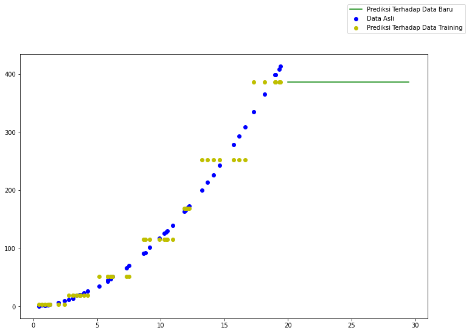

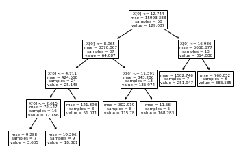

```python
fig = plt.subplots(figsize=(12, 8))
plt.scatter(x, y, c='b', label = 'Data Asli')
plt.scatter(x_train, y_predict, c='y', label = 'Prediksi Terhadap Data Training')
plt.plot(x_test, y_test, c='g', label = 'Prediksi Terhadap Data Baru')
plt.legend(bbox_to_anchor=(1.1,1.2))
plt.show()
tree.plot_tree(rgr);
```

```python
rgr.feature_importances_
```

```
array([1.])
```

```python
rgr.n_features_
```

```
1
```